# SymPy-video

```python
import sys
sys.path.append('C:\Anaconda3\Lib\site-packages') # Link to my local libraries
import numpy as np
import matplotlib.pyplot as plt
plt.style.use('seaborn-whitegrid')
%matplotlib inline
sys.version
```

```
'3.5.1 |Continuum Analytics, Inc.| (default, Jan 29 2016, 15:01:46) [MSC v.1900 64 bit (AMD64)]'
```

Author: Alex Galea  
Date: September, 2016

## SymPy Tutorial

SymPy can be installed with

`pip install sympy`

To easily check if the package is already installed or has installed properly, boot up the python interpreter and try to import it.

Here is the mantra of SymPy (from the docs):

Symbolic computation deals with the computation of mathematical objects symbolically. This means that the mathematical objects are represented exactly, not approximately, and mathematical expressions with unevaluated variables are left in symbolic form.

```python
from sympy import *
```

In this tutorial we will see:

- create and use symbolic equations and functions
- evaluate analytic derivatives and integrals
- take limits, taylor series expansions
- solving equations
- LaTeX printing and code building

### Datatypes, constants, built-in functions

**Constants**

```python
pi, type(pi), pi.evalf(30)
```

```
(pi, sympy.core.numbers.Pi, 3.14159265358979323846264338328)
```

```python
pi.evalf() == np.pi
```

```
True
```

```python
oo, oo > 10e15
```

```
(oo, True)
```

**Complex numbers**

```python
complex_number = 2 + 4*I
complex_number
```

```
2 + 4*I
```

```python
expand(complex_number**2)
```

```
-12 + 16*I
```

**Trigonometric functions**

```python
cos(2*pi), cos(3.9)
```

```
(1, -0.725932304200140)
```

```python
cos(4), cos(4).evalf()
```

```
(cos(4), -0.653643620863612)
```

```python
sin(4.4*pi)
```

$$\sin{\left (0.4 \pi \right )}$$

```python
x = 54003
sin(x*pi) == sin(x*pi - 2*pi)
```

```
True
```

```python
x = np.linspace(0, 3*pi.evalf(), 50)
```

```
---------------------------------------------------------------------------
TypeError                                 Traceback (most recent call last)
<ipython-input-24-9f6562176a65> in <module>()
----> 1 x = np.linspace(0, 3*pi.evalf(), 50)

C:\Anaconda3\Lib\site-packages\numpy\core\function_base.py in linspace(start, stop, num, endpoint, retstep, dtype)
     91     stop = stop * 1.
     92
---> 93     dt = result_type(start, stop, float(num))
     94     if dtype is None:
     95         dtype = dt

TypeError: data type not understood
```

```python
type(3*pi.evalf())
```

```
sympy.core.numbers.Float
```

```python
float(3*pi), type(float(3*pi))
```

```
(9.42477796076938, float)
```

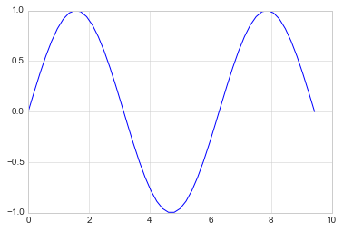

```python
x = np.linspace(0, float(3*pi), 50)
plt.plot(x, [sin(x_i) for x_i in x])
```

**Other built-in functions**

```python
exp(59), exp(59.1)
```

```
(exp(59), 4.64305555898613e+25)
```

```python
type(exp(59)), type(exp(59.1))
```

```
(exp, sympy.core.numbers.Float)
```

```python
y = exp(-2) * (2 + (1 + (exp(-3))))
y
```

```
(exp(-3) + 3)*exp(-2)
```

```python
expand(y)
```

```
exp(-5) + 3*exp(-2)
```

```python
factorial(4) == 4 * 3 * 2 * 1
```

```
True
```

```python
n = 20
[binomial(n, k) for k in range(n+1)]
```

```
[1,
 20,
 190,
 1140,
 4845,
 15504,
 38760,
 77520,
 125970,
 167960,
 184756,
 167960,
 125970,
 77520,
 38760,
 15504,
 4845,
 1140,
 190,
 20,
 1]
```

```python
np.array([binomial(n, k) for k in range(n+1)]) / sum([binomial(n, k) for k in range(n+1)])
```

```
array([1/1048576, 5/262144, 95/524288, 285/262144, 4845/1048576, 969/65536,
       4845/131072, 4845/65536, 62985/524288, 20995/131072, 46189/262144,
       20995/131072, 62985/524288, 4845/65536, 4845/131072, 969/65536,
       4845/1048576, 285/262144, 95/524288, 5/262144, 1/1048576], dtype=object)
```

```python
np.array([binomial(n, k).evalf(3) for k in range(n+1)]) / sum([binomial(n, k) for k in range(n+1)])
```

```
array([9.54e-7, 1.91e-5, 0.000181, 0.00109, 0.00462, 0.0148, 0.0370,
       0.0739, 0.120, 0.160, 0.176, 0.160, 0.120, 0.0739, 0.0370, 0.0148,
       0.00462, 0.00109, 0.000181, 1.91e-5, 9.54e-7], dtype=object)
```

### Symbolic computation

**Simple calculus**

```python
symbols?
```

```python
a, g = symbols('alpha, gamma')
```

```python
f = a**2 + 500 * a / g
f
```

```
alpha**2 + 500*alpha/gamma
```

```python
diff(f, a)
```

```
2*alpha + 500/gamma
```

```python
diff(f, g)
```

```
-500*alpha/gamma**2
```

```python
diff(f, g, a)
```

```
-500/gamma**2
```

```python
integrate(f, g, a)
```

```
alpha**3*gamma/3 + 250*alpha**2*log(gamma)
```

```python
result = integrate(f, (g, -1, 1), (a, 0, 1))
result
```

```
2/3 - 250*I*pi
```

```python
type(result)
```

```
sympy.core.add.Add
```

```python
complex(result), type(complex(result))
```

```
((0.6666666666666666-785.3981633974483j), complex)
```

**Difficult calculus**

```python
r, b, c, d = symbols('r, b, c, d')
beta = (1 + c * b * r) * (1 - exp(-d * b * r)) * exp(-b * r) / (d * b * r)
```

```python
beta
```

```
(1 - exp(-b*d*r))*(b*c*r + 1)*exp(-b*r)/(b*d*r)
```

```python
pretty(beta)
```

```
'⎛     -b⋅d⋅r⎞              -b⋅r\n⎝1 - ℯ      ⎠⋅(b⋅c⋅r + 1)⋅ℯ    \n───────────────────────────────\n             b⋅d⋅r             '
```

```python
pprint(beta)
```

```
⎛     -b⋅d⋅r⎞              -b⋅r
⎝1 - ℯ      ⎠⋅(b⋅c⋅r + 1)⋅ℯ
───────────────────────────────
             b⋅d⋅r
```

```python
diff(beta, r)
```

```
c*(1 - exp(-b*d*r))*exp(-b*r)/(d*r) + (b*c*r + 1)*exp(-b*r)*exp(-b*d*r)/r - (1 - exp(-b*d*r))*(b*c*r + 1)*exp(-b*r)/(d*r) - (1 - exp(-b*d*r))*(b*c*r + 1)*exp(-b*r)/(b*d*r**2)
```

```python
integrate(beta, r)
```

```
(b*c*Piecewise((r, Eq(b, 0)), (-exp(-b*r)/b, True)) - b*c*Piecewise((r, Or(Eq(b, 0), Eq(d, -1))), (-1/(b*d*exp(b*r)*exp(b*d*r) + b*exp(b*r)*exp(b*d*r)), True)) + Ei(b*r*exp_polar(I*pi)) - Ei(b*r*exp_polar(I*pi)*polar_lift(d + 1)))/(b*d)
```

```python
beta_f = lambdify((r, b, c, d), beta)
beta_f
```

```
<function numpy.<lambda>>
```

```python
beta_f(4, 1, 1, 1)
```

```
0.02247522032603958
```

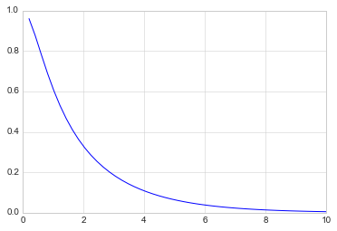

```python
b_, c_, d_ = 0.5, 3.5, 5.0
r_ = np.linspace(0, 10, 50)
plt.plot(r_, [beta_f(r_i, b_, c_, d_) for r_i in r_])
```

```python
my_beta = beta.subs([(b, 0.5), (c, 3.5), (d, 5.0)])
my_beta
```

```
0.4*(1 - exp(-2.5*r))*(1.75*r + 1)*exp(-0.5*r)/r
```

```python
limit(my_beta, r, oo)
```

```
0
```

```python
limit(my_beta, r, 0)
```

```
1.00000000000000
```

```python
%%time
result = integrate(my_beta, (r, 0, oo))
print(result.evalf())
```

[output not shown]

```python
%%time
my_beta_f = lambdify(r, my_beta)
r_ = np.arange(0.01, 1000, 0.01)
result = np.trapz(y=[my_beta_f(r_i) for r_i in r_],
                  x=r_)
print(result)
```

```
1.87337108107
Wall time: 171 ms
```

```python
%%time
result = integrate(my_beta, (r, 0.01, oo))
print(result.evalf())
```

```
1.8733708735337 + 0.e-20*I
Wall time: 3.28 s
```

**Taylor expansions**

```python
x = symbols('x')
pprint(sin(x).series(x))
pprint(sin(x).series(x, 0, 15))
```

```
     3     5
    x     x     ⎛ 6⎞
x - ── + ─── + O⎝x ⎠
    6    120
     3     5     7       9        11          13
    x     x     x       x        x           x          ⎛ 15⎞
x - ── + ─── - ──── + ────── - ──────── + ────────── + O⎝x  ⎠
    6    120   5040   362880   39916800   6227020800
```

```python
beta.series(r)
```

$$1 + r \left(b c - \frac{b d}{2} - b\right) + r^{2} \left(- \frac{c d}{2} b^{2} - b^{2} c + \frac{b^{2} d^{2}}{6} + \frac{b^{2} d}{2} + \frac{b^{2}}{2}\right) + r^{3} \left(\frac{b^{3} c}{6} d^{2} + \frac{c d}{2} b^{3} + \frac{b^{3} c}{2} - \frac{b^{3} d^{3}}{24} - \frac{b^{3} d^{2}}{6} - \frac{b^{3} d}{4} - \frac{b^{3}}{6}\right) + r^{4} \left(- \frac{b^{4} c}{24} d^{3} - \frac{b^{4} c}{6} d^{2} - \frac{c d}{4} b^{4} - \frac{b^{4} c}{6} + \frac{b^{4} d^{4}}{120} + \frac{b^{4} d^{3}}{24} + \frac{b^{4} d^{2}}{12} + \frac{b^{4} d}{12} + \frac{b^{4}}{24}\right) + r^{5} \left(\frac{b^{5} c}{120} d^{4} + \frac{b^{5} c}{24} d^{3} + \frac{b^{5} c}{12} d^{2} + \frac{c d}{12} b^{5} + \frac{b^{5} c}{24} - \frac{b^{5} d^{5}}{720} - \frac{b^{5} d^{4}}{120} - \frac{b^{5} d^{3}}{48} - \frac{b^{5} d^{2}}{36} - \frac{b^{5} d}{48} - \frac{b^{5}}{120}\right) + \mathcal{O}\left(r^{6}\right)$$

```python
my_beta.series(r)
```

```
1.0 - 1.27083333333333*r**2 + 1.78645833333333*r**3 - 1.55078125*r**4 + 1.01232638888889*r**5 + O(r**6)
```

**Equations and solving for unknowns**

```python
x, y = symbols('x, y')
coef = np.random.random(size=4)
RHS = sum([c * x**i for i, c in enumerate(coef)])
equation = Eq(y, RHS)
```

```python
RHS
```

```
0.783295433659948*x**3 + 0.918714250315763*x**2 + 0.223110905586017*x + 0.226296124385302
```

```python
type(RHS), type(equation)
```

```
(sympy.core.add.Add, sympy.core.relational.Equality)
```

```python
equation
```

```
                       3                      2
y = 0.783295433659948⋅x  + 0.918714250315763⋅x  + 0.223110905586017⋅x + 0.2262


96124385302
```

```python
my_eqn = equation.subs([(x, 0)])
my_eqn
```

[output not shown]

```python
my_y = solve(my_eqn, y)[0]
my_y
```

```
0.226296124385302
```

```python
my_eqn = equation.subs([(y, 0)])
my_eqn
```

```
                       3                      2
0 = 0.783295433659948⋅x  + 0.918714250315763⋅x  + 0.223110905586017⋅x + 0.2262


96124385302
```

```python
my_x = solve(my_eqn, x)
my_x
```

[output not shown]

```python
equation.subs([(y, 0), (x, 0)])
```

```
False
```

```python
# What do the roots give when plugged in?
print(solve(equation.subs([(x, my_x[0])]), y)[0])
print(solve(equation.subs([(x, my_x[1])]), y)[0])
print(solve(equation.subs([(x, my_x[2])]), y)[0])
```

[output not shown]

### Pretty printing

```python
init_session()
```

```
IPython console for SymPy 1.0 (Python 3.5.1-64-bit) (ground types: python)

These commands were executed:
>>> from __future__ import division
>>> from sympy import *
>>> x, y, z, t = symbols('x y z t')
>>> k, m, n = symbols('k m n', integer=True)
>>> f, g, h = symbols('f g h', cls=Function)
>>> init_printing()

Documentation can be found at http://docs.sympy.org/1.0/
```

```python
x, y = symbols('x, y')
coef = np.random.random(size=4)
RHS = sum([c * x**i for i, c in enumerate(coef)])
equation = Eq(y, RHS)
equation
```

$$y = 0.979173939938694 x^{3} + 0.268119149539736 x^{2} + 0.893564131571289 x + 0.733538724159242$$

```python
r, b, c, d = symbols('r, b, c, d')
beta = (1 + c * b * r) * (1 - exp(-d * b * r)) * exp(-b * r) / (d * b * r)
beta
```

$$\frac{e^{- b r}}{b d r} \left(1 - e^{- b d r}\right) \left(b c r + 1\right)$$

```python
beta.series(r)
```

$$1 + r \left(b c - \frac{b d}{2} - b\right) + r^{2} \left(- \frac{c d}{2} b^{2} - b^{2} c + \frac{b^{2} d^{2}}{6} + \frac{b^{2} d}{2} + \frac{b^{2}}{2}\right) + r^{3} \left(\frac{b^{3} c}{6} d^{2} + \frac{c d}{2} b^{3} + \frac{b^{3} c}{2} - \frac{b^{3} d^{3}}{24} - \frac{b^{3} d^{2}}{6} - \frac{b^{3} d}{4} - \frac{b^{3}}{6}\right) + r^{4} \left(- \frac{b^{4} c}{24} d^{3} - \frac{b^{4} c}{6} d^{2} - \frac{c d}{4} b^{4} - \frac{b^{4} c}{6} + \frac{b^{4} d^{4}}{120} + \frac{b^{4} d^{3}}{24} + \frac{b^{4} d^{2}}{12} + \frac{b^{4} d}{12} + \frac{b^{4}}{24}\right) + r^{5} \left(\frac{b^{5} c}{120} d^{4} + \frac{b^{5} c}{24} d^{3} + \frac{b^{5} c}{12} d^{2} + \frac{c d}{12} b^{5} + \frac{b^{5} c}{24} - \frac{b^{5} d^{5}}{720} - \frac{b^{5} d^{4}}{120} - \frac{b^{5} d^{3}}{48} - \frac{b^{5} d^{2}}{36} - \frac{b^{5} d}{48} - \frac{b^{5}}{120}\right) + \mathcal{O}\left(r^{6}\right)$$

```python
diff(beta, r)
```

$$\frac{c e^{- b r}}{d r} \left(1 - e^{- b d r}\right) + \frac{1}{r} \left(b c r + 1\right) e^{- b r} e^{- b d r} - \frac{e^{- b r}}{d r} \left(1 - e^{- b d r}\right) \left(b c r + 1\right) - \frac{e^{- b r}}{b d r^{2}} \left(1 - e^{- b d r}\right) \left(b c r + 1\right)$$

```python
print(latex(beta))
```

```
\frac{e^{- b r}}{b d r} \left(1 - e^{- b d r}\right) \left(b c r + 1\right)
```

```python
print(latex(diff(beta, r, b, d)))
```

[output not shown]

Look at all the LaTeX I wrote ;)

$\frac{\partial{d}}{\partial{d}} \frac{\partial{d}}{\partial{b}} \frac{\partial{d}}{\partial{r}} \Big[\frac{e^{- b r}}{b d r} \left(1 - e^{- b d r}\right) \left(b c r + 1\right)\Big] = \left(- 2 b c r e^{- b d r} - \frac{2 b}{d} c r e^{- b d r} + b d r \left(b c r + 1\right) e^{- b d r} + 2 b r \left(b c r + 1\right) e^{- b d r} + \frac{b r}{d} \left(b c r + 1\right) e^{- b d r} - \frac{c}{d} e^{- b d r} + \frac{2 c}{d^{2}} \left(1 - e^{- b d r}\right) + \frac{1}{d} \left(b c r + 1\right) e^{- b d r} - \frac{1}{d^{2}} \left(1 - e^{- b d r}\right) \left(b c r + 1\right) + \frac{c}{b d^{2} r} \left(1 - e^{- b d r}\right) + \frac{e^{- b d r}}{b d r} \left(b c r + 1\right) - \frac{1}{b d^{2} r} \left(1 - e^{- b d r}\right) \left(b c r + 1\right) - \frac{1}{b^{2} d^{2} r^{2}} \left(1 - e^{- b d r}\right) \left(b c r + 1\right)\right) e^{- b r}$